# Speed-dating(Supervised learning)

### Classification

We are going to use supervised learning to determine the possibility of a second date based on the outcomes of the first date.*A second date is only guaranteed if both parties aggree*.

#### dataset

Our dataset contains the following labels

1. Age-ages of the parties
2. Race- their racial affiliations
3. Attractive-whether the partner is attrative (on a scale of one to ten)
4. Sincere- How sincere the individual is (1-10)
5. Fun: How fun is the partner(1-10)
6. Shared interest: To what extent do the other party identify with your interests or hobbies(1-10)
7. Partneryes: How confident are you that your partner will want a second date
8. Like: How much do you like the other person
9. Decision: Individual decision of the parties as to whether they would like to go on a second date
10. ambitious: how ambitious is your partner.(1-10)
11. Second_date: A binary class based on the decision made by both parties as to whether they would prefer a second date(1: for yes and 0: for no).

```r
# load libraries
library(ggplot2)
library(MASS)
library(rpart)
library(mlbench)
library(caret)
library(e1071)
library(randomForest)
library(ggplot2)
library(lattice)
library(nnet)
library(pROC)
library(ROCR)
library(class)
library(magrittr)
library(dplyr)
library(tidyr)
library(rpart.plot)
library(Amelia)
library(FSelector)
# dataset
data <- read.csv(file.choose(), header = TRUE, stringsAsFactors = TRUE)
```

```r
# response label(second_date)
second_date  <- matrix(nrow = nrow(data), ncol = 1)

for (i in 1:nrow(data)){
  if (data[i,1] + data[i,2] == 2){
    second_date[i]  <- 1
  } else {
    second_date[i]  <- 0
  }
}
# include the column in the new dataset
data  <- cbind(second_date, data)
```

#### data preprocessing

handling the missing values and also introduce some functions for ease of computations.

```r
#  create a functin to add the missing values to a list
lappend <- function (lst, ...){
  lst <- c(lst, list(...))
  return(lst)
}
# add the missing values
na_index <- list()
for (i in 1:ncol(data)){
  na_index <- lappend(na_index, which(is.na(data[,i])))
}
```

```r
# encode the non-numeric labels so that they are compatible with the method we'll use for handling null values
data$RaceM <- as.numeric(data$RaceM)
data$RaceF <- as.numeric(data$RaceF)

# use amelia method  to impute the missing values
data <- amelia(x = data, m = 1, boot.type = "none")$imputations$imp1
```

```
-- Imputation 1 --

  1  2  3  4  5  6
```

```r
# we need to confirm that the method has sorted the missing values
a_index <- list()
for (i in 1:ncol(data)){
  na_index <- lappend(na_index, which(is.na(data[,i])))
}
na_index <- matrix(na_index, ncol = length(na_index), nrow = 1)
print(na_index)
```

```
     [,1]      [,2]      [,3]      [,4]      [,5]      [,6]      [,7]      [,8]      [,9]      [,10]
[1,] Integer,0 Integer,0 Integer,0 Integer,2 Integer,4 Integer,4 Integer,4 Integer,3 Integer,5 Integer,0
     [,11]     [,12]     [,13]     [,14]     [,15]     [,16]     [,17]     [,18]     [,19]     [,20]
[1,] Integer,0 Integer,3 Integer,2 Integer,5 Integer,3 Integer,8 Integer,3 Integer,6 Integer,6 Integer,17
     [,21]      [,22]      [,23]      [,24]     [,25]     [,26]     [,27]     [,28]     [,29]     [,30]
[1,] Integer,10 Integer,27 Integer,30 Integer,0 Integer,0 Integer,0 Integer,0 Integer,0 Integer,0 Integer,0
     [,31]     [,32]     [,33]     [,34]     [,35]     [,36]     [,37]     [,38]     [,39]     [,40]
[1,] Integer,0 Integer,0 Integer,0 Integer,0 Integer,0 Integer,0 Integer,0 Integer,0 Integer,0 Integer,0
     [,41]     [,42]     [,43]     [,44]     [,45]     [,46]
[1,] Integer,0 Integer,0 Integer,0 Integer,0 Integer,0 Integer,0
```

```r
# a function for computing statistical measures
summaryStatistics <- function(array){
  Mean <- mean(array)
  Std <- sd(array)
  Min <- min(array)
  Max <- max(array)
  Range <- Max - Min
  output <- data.frame("Mean" = Mean, "Std Dev" = Std, "Min" =  Min,"Max" = Max, "Range" = Range)
  return(output)
}
# lets look at some summaries
summaryStatistics(data$AgeM)
```

| Mean | Std.Dev | Min | Max | Range |
| --- | --- | --- | --- | --- |
| 26.57384 | 3.515817 | 18 | 42 | 24 |

```r
summaryStatistics(data$AgeF)
```

| Mean | Std.Dev | Min | Max | Range |
| --- | --- | --- | --- | --- |
| 26.21237 | 3.993963 | 19 | 55 | 36 |

```r
NA
```

*from above summaries the age in males and females averages at 26*

#### data exploration

Here we intend to visualise some patterns from the data from which we can derive insights about the data

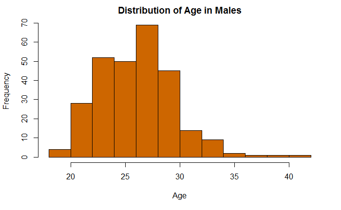

```r
# distribution of ages in both sexes
hist(data$AgeM, main = "Distribution of Age in Males", xlab = "Age", ylab = "Frequency", col = "darkorange3")
```

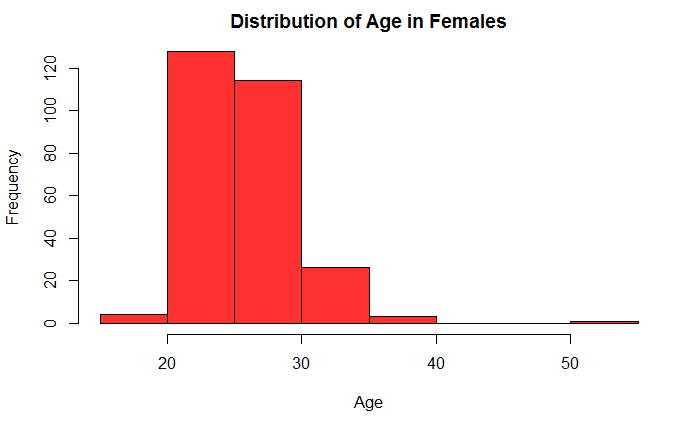

```r
hist(data$AgeF, main = "Distribution of Age in Females", xlab = "Age", ylab = "Frequency", col = "firebrick1")
```

```r
# let us create age classes for ease of analysis based on age
data<-data%>%
  mutate(age_M=ifelse(AgeM<10,'below 10',
  ifelse(AgeM<20,'10-20',
         ifelse(AgeM<30,'21-30',
                ifelse(AgeM<40,'31-40',
                       ifelse(AgeM<50,'41-50',
                              ifelse(AgeM<60,'51-60',
                                     ifelse(AgeM>60,'60+',NA))))))))
data<-data%>%
  mutate(Age_F=ifelse(AgeF<10,'below 10',
  ifelse(AgeF<20,'10-20',
         ifelse(AgeF<30,'21-30',
                ifelse(AgeF<40,'31-40',
                       ifelse(AgeF<50,'41-50',
                              ifelse(AgeF<60,'51-60',
                                     ifelse(AgeF>60,'60+',NA))))))))
```

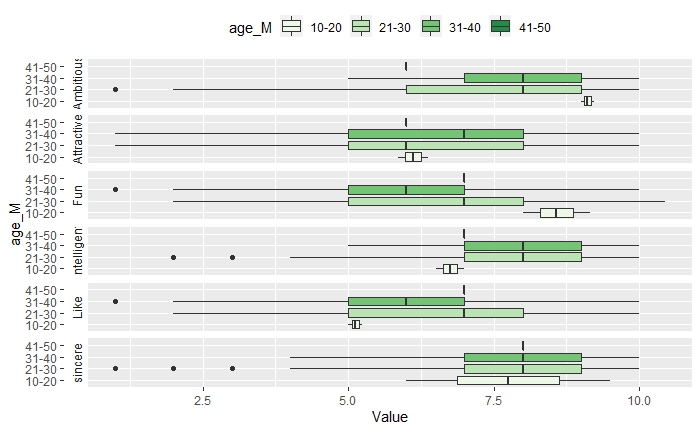

```r
#  a label map for enhance visualization of the different variables on a box plot
label_map <- c(LikeF = "Like",
 AttractiveF = "Attractive",
 IntelligentF = "intelligent",
 AmbitiousF="Ambitious",
 FunF="Fun",
 SincereF="sincere")
# how does the age factor in males affect what their partner feels about them
data %>% gather(Measurement, Value, -age_M,-Age_F,-RaceM,-RaceF,-AgeM,-AgeF,-second_date,-DecisionM,-DecisionF,-LikeM,-PartnerYesM,-PartnerYesF,-AttractiveM,-IntelligentM,-AmbitiousM,-FunM,-SharedInterestsM,-SharedInterestsF,-SincereM) %>%
 ggplot(aes(x = age_M, y = Value, fill = age_M)) +
 geom_boxplot() +
 scale_x_discrete(labels = c("below 10" = "below 10","10-20" = "10-20","21-30" = "21-30","31-40"="31-40","41-50"="41-50","51-60"="51-60","60+"="60+")) +
 scale_fill_brewer(palette = "Greens") +
 facet_grid(Measurement ~ ., switch = "y",
 labeller = labeller(Measurement = label_map)) +
 coord_flip() +
 theme(strip.background = element_blank()) +
 theme(legend.position="top")
```

*ages between 10 and 20 generally perform poorly in almost all the aspects except that they are deemed to be more ambitious and fun.*

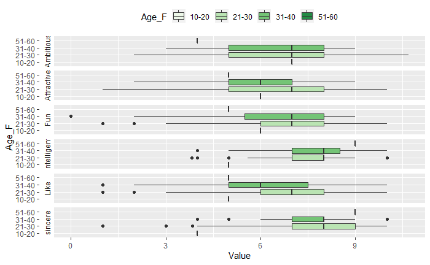

```r
# how does the age in female affect how the other partner feels about them
label_map <- c(LikeM = "Like",
 AttractiveM = "Attractive",
 IntelligentM = "intelligent",
 AmbitiousM="Ambitious",
 FunM="Fun",
 SincereM="sincere")
data %>% gather(Measurement, Value, -age_M,-Age_F,-RaceM,-RaceF,-AgeM,-AgeF,-second_date,-DecisionM,-DecisionF,-LikeF,-PartnerYesM,-PartnerYesF,-AttractiveF,-IntelligentF,-AmbitiousF,-FunF,-SharedInterestsM,-SharedInterestsF,-SincereF) %>%
 ggplot(aes(x = Age_F, y = Value, fill = Age_F)) +
 geom_boxplot() +
 scale_x_discrete(labels = c("below 10" = "below 10","10-20" = "10-20","21-30" = "21-30","31-40"="31-40","41-50"="41-50","51-60"="51-60","60+"="60+")) +
 scale_fill_brewer(palette = "Greens") +
 facet_grid(Measurement ~ ., switch = "y",
 labeller = labeller(Measurement = label_map)) +
 coord_flip() +
 theme(strip.background = element_blank()) +
 theme(legend.position="top")
```

*Females in the ages of 21-40 have averagely good scores in all the aspects. Again the ages below 20 have low score in all aspects.*

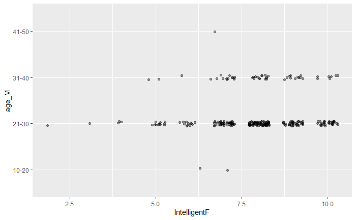

```r
# intelligence bias by race and age
# males
data %>%
 ggplot(aes(x = IntelligentF, y = age_M)) +
 geom_jitter(height = 0.05, width = 0.3, alpha=0.4)
```

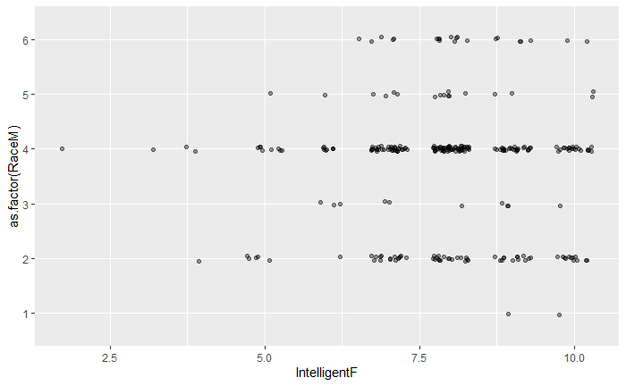

```r
data %>%
 ggplot(aes(x = IntelligentF, y = as.factor(RaceM))) +
 geom_jitter(height = 0.05, width = 0.3, alpha=0.4)
```

*Males in the ages of 21-30 have a good score for intelligence. while in terms of race, the race with index of 4 gives a very good score*

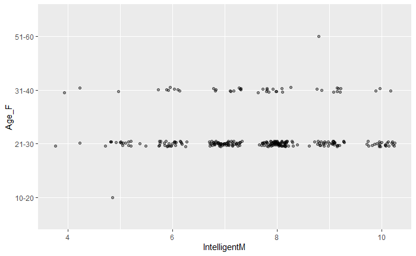

```r
# females
data %>%
 ggplot(aes(x = IntelligentM, y = Age_F)) +
 geom_jitter(height = 0.05, width = 0.3, alpha=0.4)
```

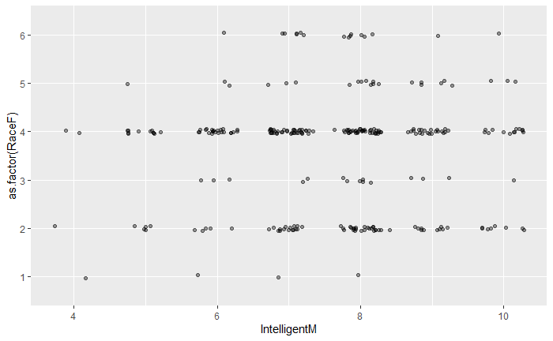

```r
data %>%
 ggplot(aes(x = IntelligentM, y = as.factor(RaceF))) +
 geom_jitter(height = 0.05, width = 0.3, alpha=0.4)
```

*The bias on Intelligence by age and race is also similar in females as seen in above two plots*

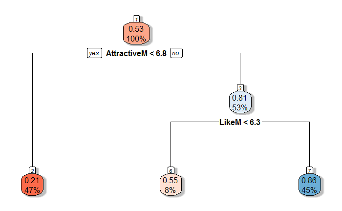

```r
# what features/labels are likely to influence a yes to a second date
# males
males_data<-data%>%select(c(DecisionM,LikeM,AttractiveM,AmbitiousM,AgeF,IntelligentM,FunM,SincereM))
tree<-rpart(DecisionM~., data=males_data, cp=.02)
# visualize
rpart.plot(tree,box.palette = "RdBu",shadow.col = "gray", nn=TRUE)
```

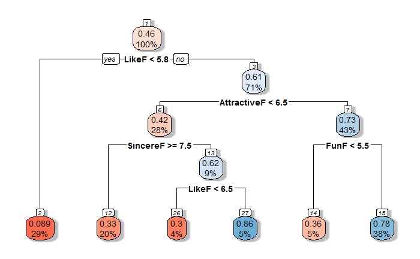

```r
# females
female_data<-data%>%select(c(DecisionF,LikeF,AttractiveF,AmbitiousF,AgeM,IntelligentF,FunF,SincereF))
tree<-rpart(DecisionF~., data=female_data, cp=.02)
# visualize
rpart.plot(tree,box.palette = "RdBu",shadow.col = "gray", nn=TRUE)
```

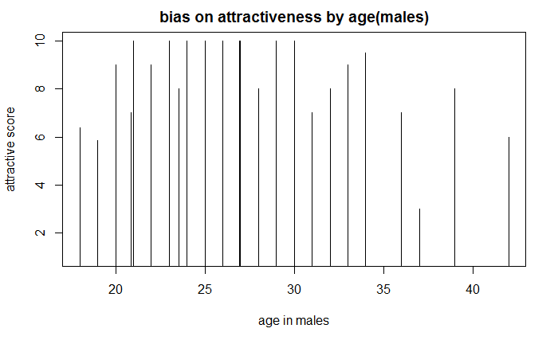

```r
# what is the bias on attraction by age
# males
data %$% plot(AgeM,AttractiveF, main="bias on attractiveness by age(males)", type="h",
 xlab="age in males", ylab="attractive score")
```

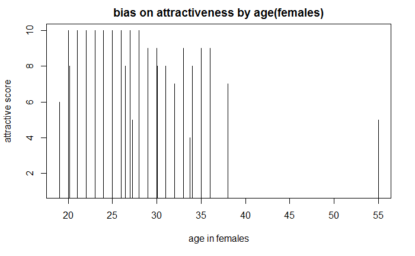

```r
# females
data %$% plot(AgeF, AttractiveM, main="bias on attractiveness by age(females)", type="h",
 xlab="age in females", ylab="attractive score")
```

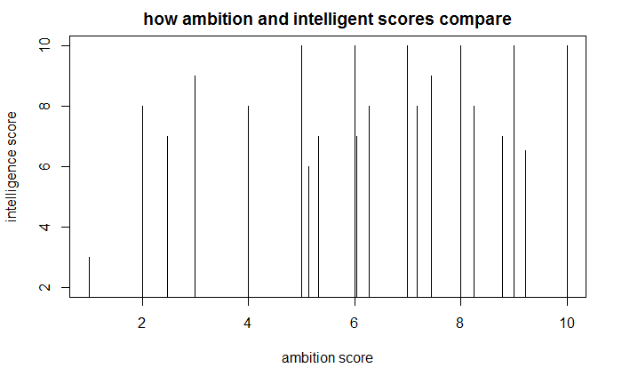

```r
# hypothesis: intelligent people tend to be more ambitious
# males
data %$% plot(AmbitiousF,IntelligentF, main="how ambition and intelligent scores compare", type="h",
 xlab="ambition score", ylab="intelligence score")
```

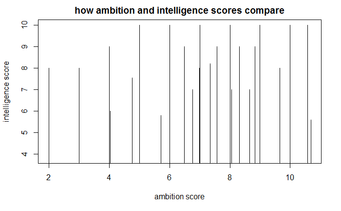

```r
# females
data %$% plot(AmbitiousM,IntelligentM, main="how ambition and intelligence scores compare", type="h",
 xlab="ambition score", ylab="intelligence score")
```

#### Feature selection

We need to indentify the labels that are more important to our target variable(second_date)

```r
# we need to scale the age labels so the mean and variance of the datapoints so that they have the best effect to the models
data$AgeM <- scale(data$AgeM)
data$AgeF <- scale(data$AgeF)

# also we need to remove the labels we added earlier during exploration
data%>% select(c(-age_M, -Age_F))->data

################################################################################################
#Feature Selection
corr <- cor(data)
# the correlation matrix
#corr

#Converting all Columns to Numeric prior to Input
for (i in 1:ncol(data)){
  data[,i] <- as.integer(data[,i])
}

#Random Forest Feature Selection Based on Importance of Classification
data$second_date <- as.factor(data$second_date)
featImport <- random.forest.importance(second_date ~., data = data, importance.type = 1)
columns <- cutoff.k.percent(featImport, 0.4)
columns
```

```
[1] "DecisionF"        "DecisionM"        "FunF"             "AttractiveM"      "SharedInterestsF"
[6] "LikeM"            "LikeF"            "AttractiveF"      "PartnerYesM"
```

#### model training

Since this is classification problem we will use three algorithms to train the model;

1. logistic regression
2. Bayesian classifier
3. KNN

*logistic regression:It is almost the best algorithm and also we’ll use it as baseline for evaluting other algorithms. We will evaluate the perfomance basd on AUC score*

```r
processedData <- data[, columns]
```

```r
# Method 1: Logistic Regression
# we wil vary the value for lambda so that we can see which one gives a good AUC score
lambda <- seq(0.01,0.9,0.01)
AUC<-c()
for (i in 1:length(lambda))
{
  rows <- sample(1:nrow(processedData), nrow(processedData)/2)
  logReg <- glm(as.factor(second_date[rows]) ~., data = processedData[rows, ], family = binomial(link = "logit"), method = "glm.fit")
  y_h <- ifelse(logReg$fitted.values >= lambda[i], 1, 0)
  AUC <- append(roc(y_h, as.numeric(second_date[-rows]))$auc, AUC)
}
```

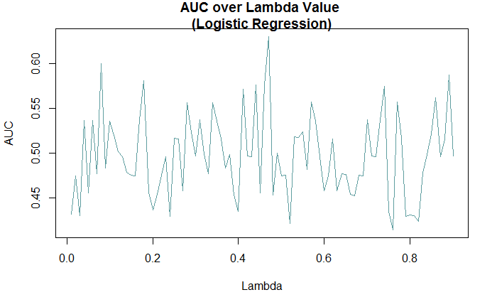

```r
# Looking at the AUC scores for our lambda values
plot(lambda,AUC, main = "AUC over Lambda Value \n(Logistic Regression)",
     xlab = "Lambda", ylab = "AUC", type = "l", col = "cadetblue")
```

```r
# using a lambda of 0.21
AUC <- c()
for (i in 1:length(lambda)){
  rows <- sample(1:nrow(processedData), nrow(processedData)/2)
  logReg <- glm(as.factor(second_date[rows]) ~., data = processedData[rows, ], family = binomial(link = "logit"), method = "glm.fit")
  y_h <- ifelse(logReg$fitted.values >= 0.21, 1, 0)
  AUC <- append(roc(y_h, as.numeric(second_date[-rows]))$auc, AUC)
}
```

[figure not shown]

```r
# looking at the summaries

#Summary Statistics and Various Plots
plot(AUC, main = "AUC over 100 Iterations for Logistic Regression, lambda = 0.21",
     xlab = "Iterations", ylab = "AUC", type = "l", col = "cadetblue")
```

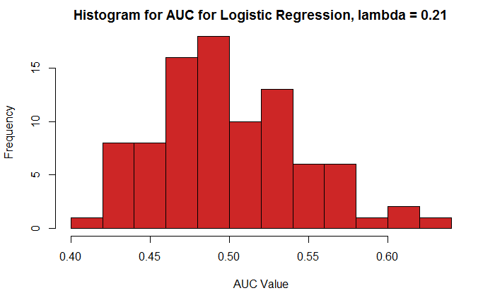

```r
hist(AUC, main = "Histogram for AUC for Logistic Regression, lambda = 0.21",
     xlab = "AUC Value", ylab = "Frequency", col = "firebrick3")
```

```r
summaryStatistics(AUC)
```

| Mean | Std.Dev | Min | Max | Range |
| --- | --- | --- | --- | --- |
| 0.5020242 | 0.04591403 | 0.4168831 | 0.6208924 | 0.2040093 |

*This model yields a very low AUC and thus is not really our preffered model, so we will implement the next algorithms and see how they compare*

```r
# Method 2: Bayesian Classifier
AUC <- c()
for (i in 1:100){
  rows <- sample(1:nrow(processedData), 92)
  bayesClass <- naiveBayes(y = as.factor(second_date[rows]), x = processedData[rows, ], data = processedData)
  y_h <- predict(bayesClass, processedData[rows, ], type = c("class"))
  AUC <- append(roc(y_h, as.numeric(second_date[rows]))$auc, AUC)
}
```

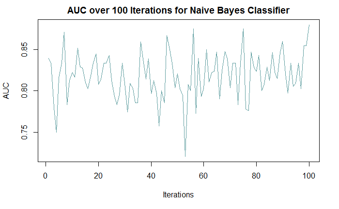

```r
#Summary Statistics and Various Plots
plot(AUC, main = "AUC over 100 Iterations for Naive Bayes Classifier",
     xlab = "Iterations", ylab = "AUC", type = "l", col = "cadetblue")
```

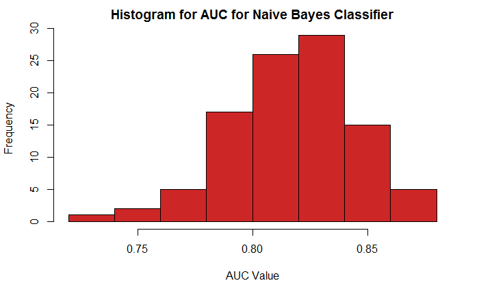

```r
hist(AUC, main = "Histogram for AUC for Naive Bayes Classifier",
     xlab = "AUC Value", ylab = "Frequency", col = "firebrick3")
```

```r
summaryStatistics(AUC)
```

| Mean | Std.Dev | Min | Max | Range |
| --- | --- | --- | --- | --- |
| 0.8181411 | 0.02806688 | 0.7205882 | 0.88 | 0.1594118 |

```r
#Predicting out of Sample:processedData[-rows] and second_date[-rows]
y_h <- predict(bayesClass, processedData[-rows, ], type = c("class"))
roc(y_h, as.numeric(second_date[-rows]))$auc
```

```
Area under the curve: 0.8235
```

*This model is generally good and it is evident from the AUC generated by predicting out of sample.*

```r
#Method 3: K-Nearest Neighbor
# we will try different k values for our model:the K value that generates a good AUC score(putting into consideration the problem of overfitting)will be used for the tuned model
K <- seq(1, 40, 1)
AUC <- c()
for (i in 1:length(K)){
  rows <- sample(1:nrow(processedData), nrow(processedData)/2)
  y_h <- knn(train = processedData[rows, ], test = processedData[rows,], cl = second_date[rows], k = K[i], use.all = TRUE)
  AUC <- append(roc(y_h, as.numeric(second_date[rows]))$auc, AUC)
}
```

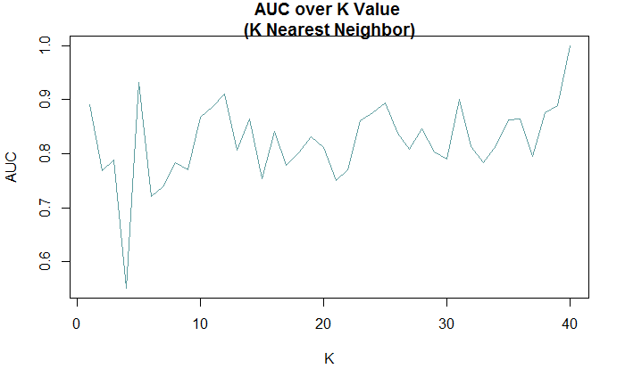

```r
#Summary Statistics and Various Plots
plot(AUC, main = "AUC over K Value \n(K Nearest Neighbor)",
     xlab = "K", ylab = "AUC", type = "l", col = "cadetblue")
```

*To avoid overfitting we will choose a relatively lower value of k but also taking into account the AUC.lets consider k value of 5 for example*

```r
# using a k value of 5
AUC <- c()
for (i in 1:100){
  y_h <- knn(train = processedData[rows, ], test = processedData[-rows,], cl = second_date[rows], k = 5, use.all = TRUE)
  AUC <- append(roc(y_h, as.numeric(second_date[rows]))$auc, AUC)
}
```

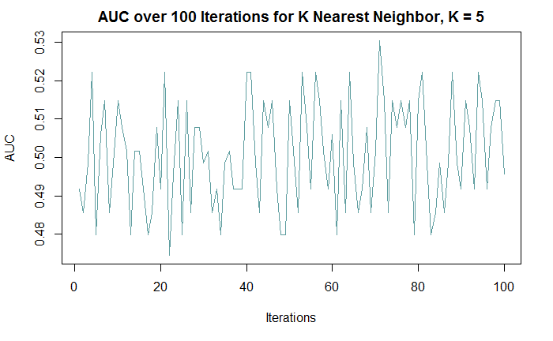

```r
#Summary Statistics and Various Plots
plot(AUC, main = "AUC over 100 Iterations for K Nearest Neighbor, K = 5",
     xlab = "Iterations", ylab = "AUC", type = "l", col = "cadetblue")
```

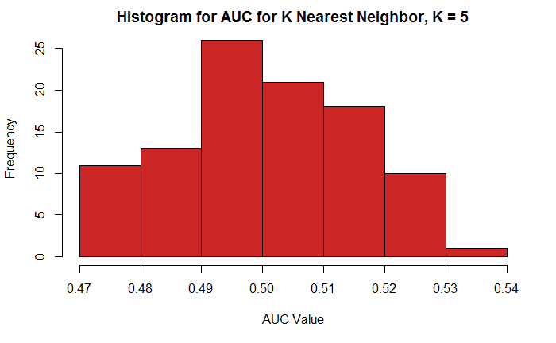

```r
hist(AUC, main = "Histogram for AUC for K Nearest Neighbor, K = 5",
     xlab = "AUC Value", ylab = "Frequency", col = "firebrick3")
```

```r
summaryStatistics(AUC)
```

| Mean | Std.Dev | Min | Max | Range |
| --- | --- | --- | --- | --- |
| 0.5008149 | 0.013854 | 0.4745298 | 0.5305556 | 0.05602577 |

```r
#Predicting out of Sample
y_h <- knn(train = processedData[rows, ], test = processedData[-rows, ], cl = second_date[-rows])
roc(y_h, as.numeric(second_date[-rows]))$auc
```

```
Area under the curve: 0.4436
```

*from above summaries the KNN algorithm is not reliable as it yields a very low score on training and predicting out of sample*

#### conclusion

Comparing above results Bayesian Model is a good choice:generally AUC score of 70 is a good indicator,We can therefore use this model for our test data.